# Práctica 10. Aplicaciones relacionadas a la demografía

Ana Escoto

26/11/2020

# Previo

## Paquetería

```r
if (!require("pacman")) install.packages("pacman") # instala pacman si se requiere
```

```r
pacman::p_load(tidyverse,
               readxl,writexl,googlesheets4, # importar hojas de cálculo
               haven, foreign, # importación de dta y sav
               sjlabelled, # etiquetas
               janitor, skimr, #limpieza y verificación
               imputeTS, # para imputar valores
               srvyr, # Para el diseño muestral
               esquisse, # para usar ggplot de manera más amigable
               #DescTools, # Paquete para estimaciones y pruebas
               #infer, # tidy way
               #broom,  # Una escobita para limpiar (pero es para arreglar)
               #estimatr, car, stargazer, ggpubr, # Para la regresión práctica 7
               #jtools, lm.beta, robustbase, sandwich, effects,
               #officer,flextable,huxtable, ggstance, kableExtra, # Para la regresión práctica 8
               #ResourceSelection, lmtest, mlogit, nnet # Práctica 9
                apyramid)
```

## Directorio

En caso que no tengas un proyecto,establecer el directorio puede ayudar

```r
rm(list=ls()) # mala práctica pero quizás necesaria porque vamos a cambiar de tema
setwd("/Users/anaescoto/Dropbox/2020/2021-1 R para Demográfos/repo/R_Demo")
```

## Base

Vamos a trabajar con las proyecciones de CONAPO. No son microdatos, sino que están agregados.

```r
pob_mit_proyecciones <- read.csv("https://github.com/aniuxa/R_Demo/raw/master/datos/pob_mit_proyecciones.csv", encoding = "latin1")
```

Son las poblaciones a mitad de julio de CONAPO (podríamos descargarlas directamente, pero yo estoy vetada)

Vamos a limpiar los nombres:

```r
pob_mit_proyecciones<-clean_names(pob_mit_proyecciones)
```

Base de ECOVID - ML

```r
ecovid0420 <- read_dta("https://github.com/aniuxa/R_Demo/raw/master/datos/ecovid0420.dta")
```

# Pirámides con datos agregados

Revisemos esta base de datos de las proyecciones de población.

```r
skimr::skim(pob_mit_proyecciones)
```

Data summary

| Name | pob_mit_proyecciones |
| --- | --- |
| Number of rows | 592460 |
| Number of columns | 7 |
| _______________________ |  |
| Column type frequency: |  |
| character | 2 |
| numeric | 5 |
| ________________________ |  |
| Group variables | None |

**Variable type: character**

| skim_variable | n_missing | complete_rate | min | max | empty | n_unique | whitespace |
| --- | --- | --- | --- | --- | --- | --- | --- |
| entidad | 0 | 1 | 6 | 19 | 0 | 33 | 0 |
| sexo | 0 | 1 | 7 | 7 | 0 | 2 | 0 |

**Variable type: numeric**

| skim_variable | n_missing | complete_rate | mean | sd | p0 | p25 | p50 | p75 | p100 | hist |
| --- | --- | --- | --- | --- | --- | --- | --- | --- | --- | --- |
| renglon | 0 | 1 | 296230.50 | 171028.61 | 1 | 148115.8 | 296230.5 | 444345.2 | 592460 | ▇▇▇▇▇ |
| ano | 0 | 1 | 2009.62 | 23.70 | 1950 | 1989.0 | 2010.0 | 2030.0 | 2050 | ▁▇▇▇▇ |
| cve_geo | 0 | 1 | 15.88 | 9.59 | 0 | 8.0 | 16.0 | 24.0 | 32 | ▇▆▇▆▇ |
| edad | 0 | 1 | 54.50 | 31.75 | 0 | 27.0 | 54.5 | 82.0 | 109 | ▇▇▇▇▇ |
| poblacion | 0 | 1 | 31142.55 | 113815.57 | 0 | 1353.0 | 8429.0 | 23210.0 | 1198088 | ▇▁▁▁▁ |

## Edad y sexo

La edad y sexo son de las variables más importantes en la demografía para explicar la estructura de una población. Las pirámides son parte esencial de lo que llamamos “Demografía estática”

```r
pob_mit_proyecciones %>%
  filter(cve_geo==0) %>%
  filter(ano==2020) %>%
  count(edad, sexo, wt=poblacion)
```

```
##     edad    sexo       n
## 1      0 Hombres 1087447
## 2      0 Mujeres 1048275
## 3      1 Hombres 1093379
## 4      1 Mujeres 1054636
## 5      2 Hombres 1100800
## 6      2 Mujeres 1061974
## 7      3 Hombres 1108402
## 8      3 Mujeres 1069224
## 9      4 Hombres 1114769
## 10     4 Mujeres 1075251
## 11     5 Hombres 1119479
## 12     5 Mujeres 1079856
## 13     6 Hombres 1122374
## 14     6 Mujeres 1082945
```

[output cut: 206 more lines]

Podemos pensar en las pirámides como un doble histograma

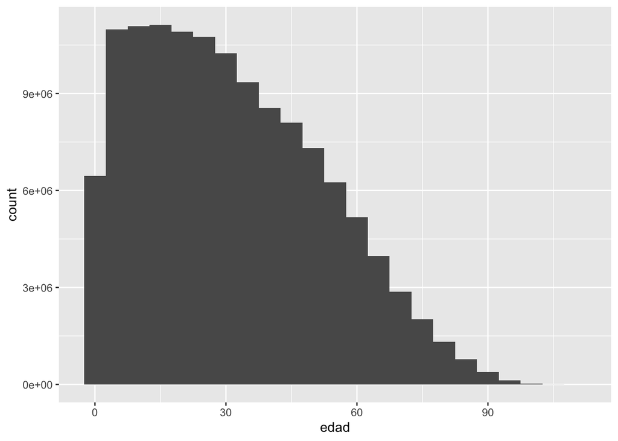

```r
pob_mit_proyecciones %>%
  filter(cve_geo==0) %>%
  filter(ano==2020) %>%
  ggplot(
    aes(edad, weight=poblacion)
  ) + geom_histogram(binwidth = 5)
```

Tendríamos que darle la vuelta para verle más el parecido

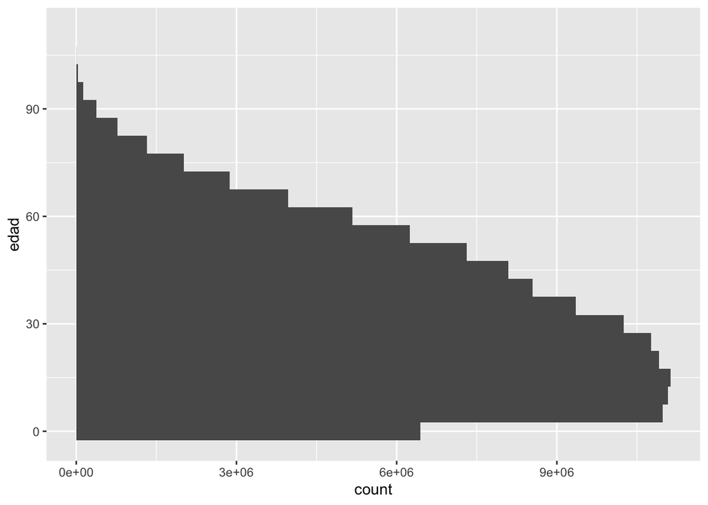

```r
pob_mit_proyecciones %>%
  filter(cve_geo==0) %>%
  filter(ano==2020) %>%
  ggplot(
    aes(edad, weight=poblacion)
  ) + geom_histogram(binwidth = 5)  + # verificar el ancho de clase
  coord_flip()
```

## Los grupos quinquenales, sí que sí

Si queremos hacerlo como gráficos de barra, seguramente queremos cortar la variable de edad. Igual este paso es esencial en la vida demográfica:

```r
pob_mit_proyecciones<-pob_mit_proyecciones %>%
  mutate(eda5=cut(edad, # la variable a cortar
                  breaks=seq(0,110, # El rango válido
                             by=5), # El ancho del intervalo
                  include.lowest=T, # para que incluya el valor más bajo dentro del intervalo
                  right=F)) # indica si el intervalo irá abierto en la derecha, ponemos un no con "FALSE"
```

Veamos esta variable:

```r
pob_mit_proyecciones %>% count(eda5, wt=poblacion)
```

```
##         eda5          n
## 1      [0,5) 1850369450
## 2     [5,10) 1798397314
## 3    [10,15) 1740546022
## 4    [15,20) 1650518583
## 5    [20,25) 1528556801
## 6    [25,30) 1415601789
## 7    [30,35) 1311311827
## 8    [35,40) 1208943818
## 9    [40,45) 1105462886
## 10   [45,50)  998015168
## 11   [50,55)  885777598
## 12   [55,60)  767255276
## 13   [60,65)  644700229
## 14   [65,70)  522585219
## 15   [70,75)  402225474
## 16   [75,80)  285455139
## 17   [80,85)  180727873
## 18   [85,90)   97828264
## 19   [90,95)   41841611
## 20  [95,100)   12408739
## 21 [100,105)    2052151
## 22 [105,110]     132230
```

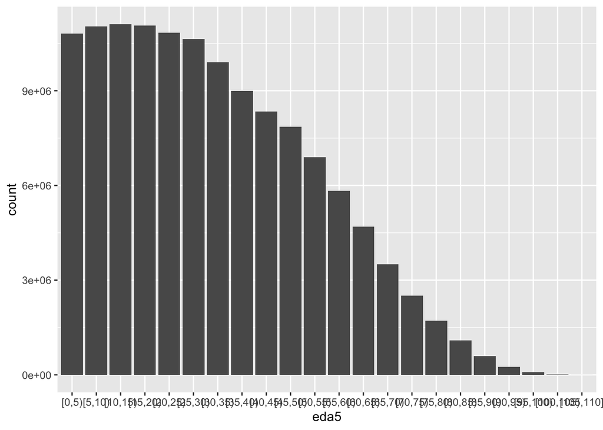

```r
### gráfico de barras de edades quinquenales
pob_mit_proyecciones %>%
  filter(cve_geo==0) %>%
  filter(ano==2020) %>%
  ggplot(aes(eda5, weights=poblacion))+
    geom_bar() # dibuja la geometría de barra
```

## La primera pirámide

Una pirámide es un histograma por sexo, donde el valor de los hombres es negativo:

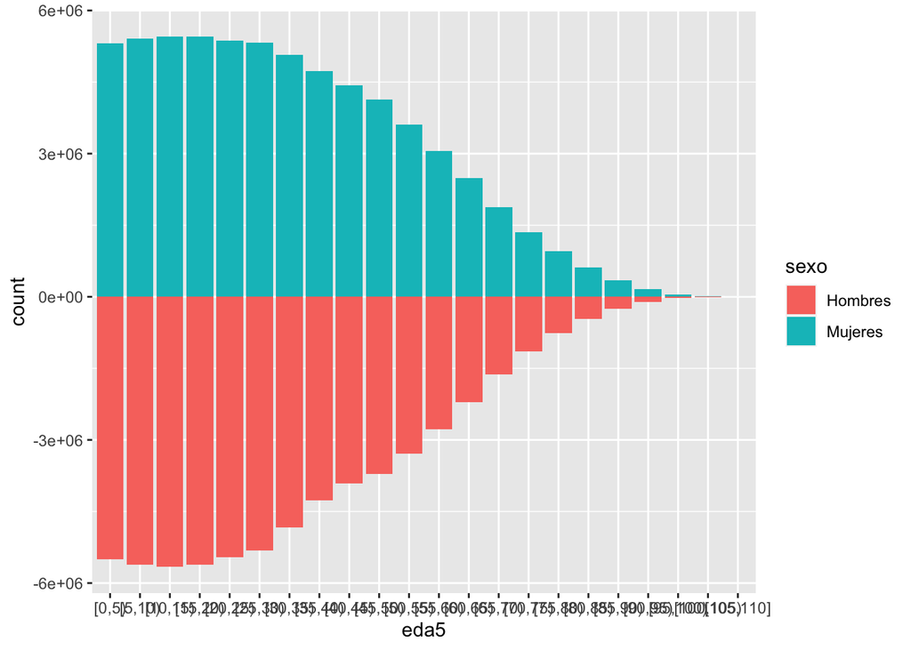

```r
pob_mit_proyecciones %>%
  filter(cve_geo==0) %>%
  filter(ano==2020) %>%
  mutate(poblacion=if_else(sexo=="Hombres", -poblacion, poblacion)) %>%
  ggplot(aes(eda5, fill=sexo, weights=poblacion))+
    geom_bar() # dibuja la geometría de barra
```

Podemos darle la vuelta y cambiarle los colores

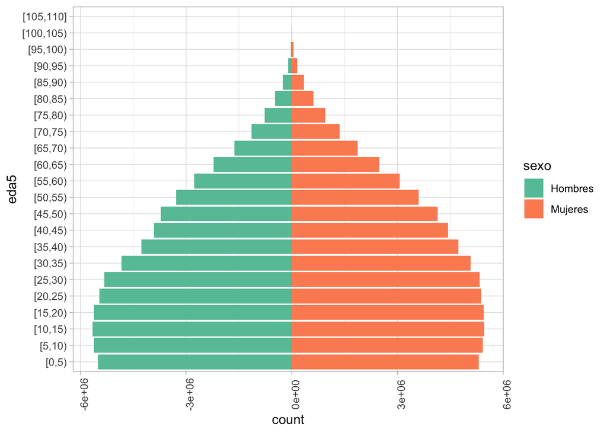

```r
pob_mit_proyecciones<-pob_mit_proyecciones %>%
  mutate(poblacion2=if_else(sexo=="Hombres", -poblacion, poblacion))

pob_mit_proyecciones %>%
  filter(cve_geo==0) %>%
  filter(ano==2020) %>%
  ggplot(aes(eda5, fill=sexo, weights=poblacion2))+
    geom_bar() + coord_flip() +
  scale_fill_brewer(palette = "Set2") +
  theme_light() +   theme(axis.text.x  =  element_text(angle = 90))
```

Como que las escalas tampoco están muy perfectas y no queremos las negativa.¡Los hombres no son personas negativas!

Veamos un poco cómo se comporta esa variable:

```r
pob_mit_proyecciones %>%
  filter(cve_geo==0) %>%
  filter(ano==2020) %>%
  count(eda5, sexo, wt=poblacion2) %>%
  summarise(max=max(n), min=min(n))
```

```
##       max      min
## 1 5457130 -5655589
```

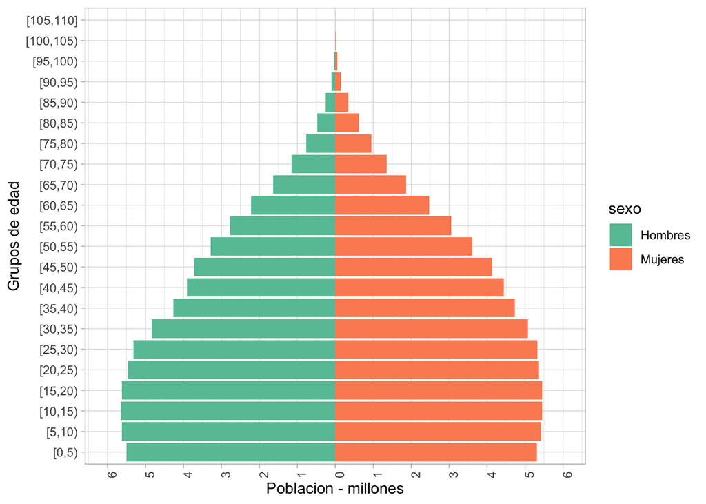

```r
pob_mit_proyecciones %>%
  filter(cve_geo==0) %>%
  filter(ano==2020) %>%
  ggplot(aes(eda5, fill=sexo, weights=poblacion2))+
    geom_bar() + coord_flip() +
   scale_y_continuous(breaks = seq(-6000000, 6000000, by=1000000), # cuántos
                      limits = c(-6000000,6000000),
                      labels = paste0(
                       as.character(c(6:0,# sustituye negativos
                         1:6) # Para lo positivo
                         )
                       )
                      )+
  labs(y="Poblacion - millones", x="Grupos de edad") +
  scale_fill_brewer(palette = "Set2") +
  theme_light() +   theme(axis.text.x  =  element_text(angle = 90))
```

Esto es para el volumen de la población ¿Cómo podemos hacer una pirámide que sea en términos de proporciones?

Vamos a necesitar el total de la población:

```r
pob_mit_proyecciones<-pob_mit_proyecciones %>%
  group_by(cve_geo, ano) %>%
  mutate(p_edo=sum(poblacion)) %>%
  ungroup()

head(pob_mit_proyecciones)
```

```
## # A tibble: 6 x 10
##   renglon   ano entidad    cve_geo  edad sexo  poblacion eda5  poblacion2  p_edo
##     <int> <int> <chr>        <int> <int> <chr>     <int> <fct>      <int>  <int>
## 1       1  1950 República…       0     0 Homb…    572103 [0,5)    -572103 2.70e7
## 2       2  1950 República…       0     0 Muje…    559162 [0,5)     559162 2.70e7
## 3       3  1950 República…       0     1 Homb…    514540 [0,5)    -514540 2.70e7
## 4       4  1950 República…       0     1 Muje…    505269 [0,5)     505269 2.70e7
## 5       5  1950 República…       0     2 Homb…    478546 [0,5)    -478546 2.70e7
## 6       6  1950 República…       0     2 Muje…    469322 [0,5)     469322 2.70e7
```

Hoy sí haremos lo mismo pero para las proporciones:

```r
pob_mit_proyecciones<-pob_mit_proyecciones %>%
  mutate(poblacion3=if_else(sexo=="Hombres", -poblacion/p_edo, poblacion/p_edo))
```

Una vez que ya tenemos nuestra variable proporcional:

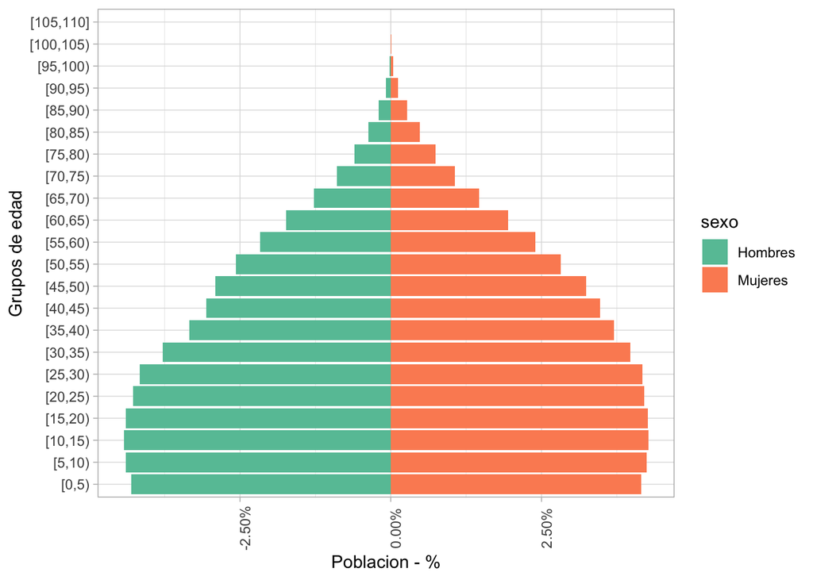

```r
pob_mit_proyecciones %>%
  filter(cve_geo==0) %>%
  filter(ano==2020) %>%
  ggplot(aes(eda5, fill=sexo, weights=poblacion3))+
    geom_bar() + coord_flip() +
   scale_y_continuous(labels = scales::percent_format(accuracy=0.01))+
  labs(y="Poblacion - %", x="Grupos de edad") +
  scale_fill_brewer(palette = "Set2") +
  theme_light() +   theme(axis.text.x  =  element_text(angle = 90))
```

Podemos hacer varias pirámides aplicando facets o grids:

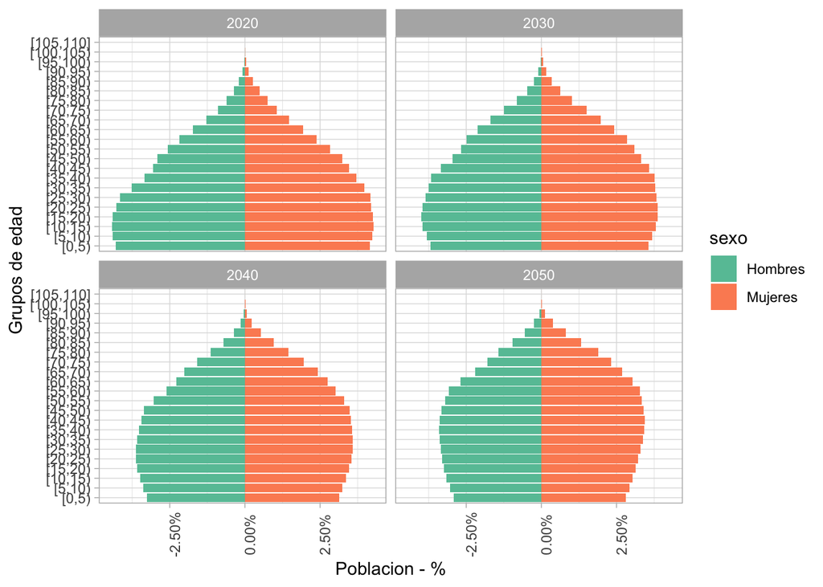

```r
pob_mit_proyecciones %>%
  filter(cve_geo==0) %>%
  filter(ano%in%seq(2020,2050, by=10)) %>%
  ggplot(aes(eda5, fill=sexo, weights=poblacion3))+
    geom_bar() + coord_flip() +
   scale_y_continuous(labels = scales::percent_format(accuracy=0.01))+
  labs(y="Poblacion - %", x="Grupos de edad") +
  scale_fill_brewer(palette = "Set2") +
  theme_light() +   theme(axis.text.x  =  element_text(angle = 90))  +
  facet_wrap(~ano)
```

# Mi primera función

Para procedimientos muy rutinarios, podemos hacer funciones

```r
mi_funcion<-function(x) {
    x<-x+1
    x
}

mi_funcion(5)
```

```
## [1] 6
```

Podemos complicarla:

```r
mi_funcion<-function(x,a) {
    x<-x+a
    x
}

mi_funcion(5,2)
```

```
## [1] 7
```

Así que podemos hacer una función de pirámide:

```r
piramide<-function(ent, ano) {
 x<-ent
 a<-ano
  pob_mit_proyecciones %>%
    filter(cve_geo==x) %>%
    filter(ano==a) %>%
    ggplot(aes(eda5, fill=sexo, weights=poblacion3))+
    geom_bar() + coord_flip() +
    scale_y_continuous(labels = scales::percent_format(accuracy=0.01))+
    labs(y="Poblacion - %", x="Grupos de edad") +
    scale_fill_brewer(palette = "Set2") +
    theme_light()
}
```

Veamos si funciona:

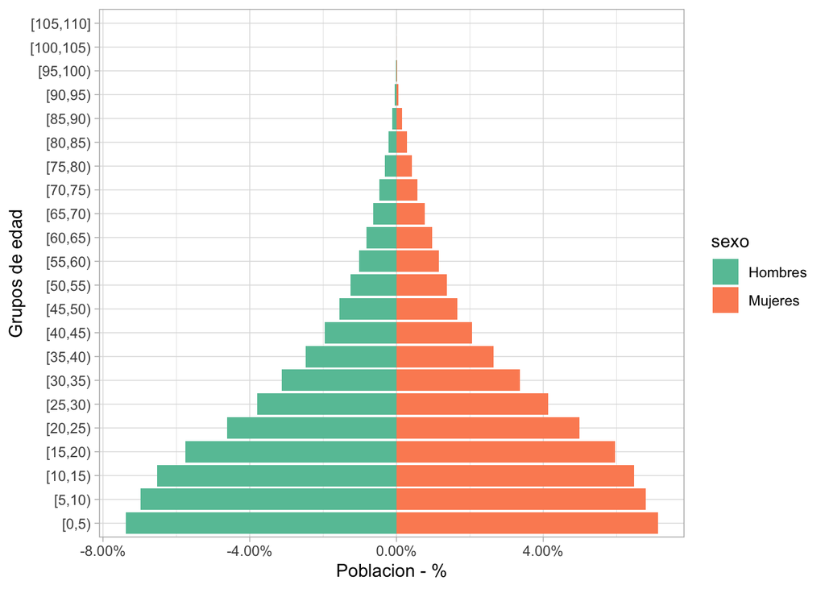

```r
piramide(1, 1990)
```

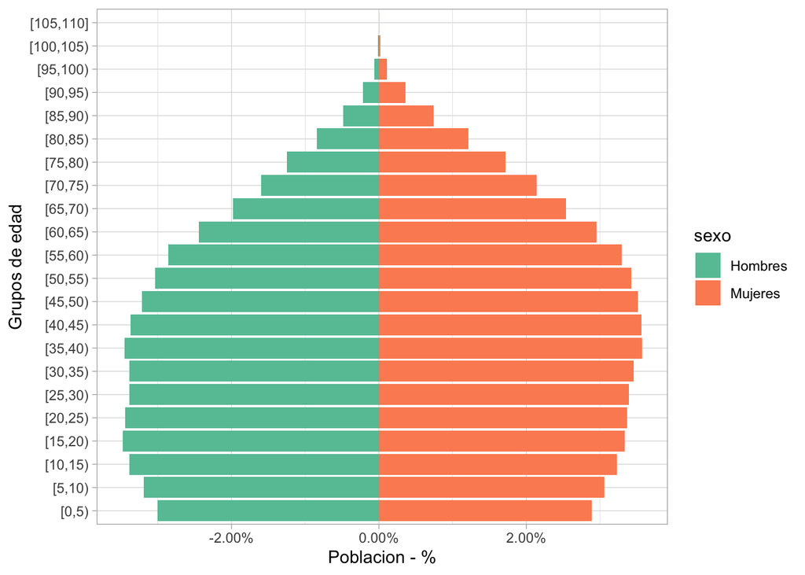

```r
piramide(12, 2050)
```

# Pirámides con bases de datos no agrupadas

Vamos a hacer un ejemplo de edad simple, y de cómo hacemos cuando los datos no están agrupados. Lo más fácil para volver negativos a los hombres es crear una nueva variable

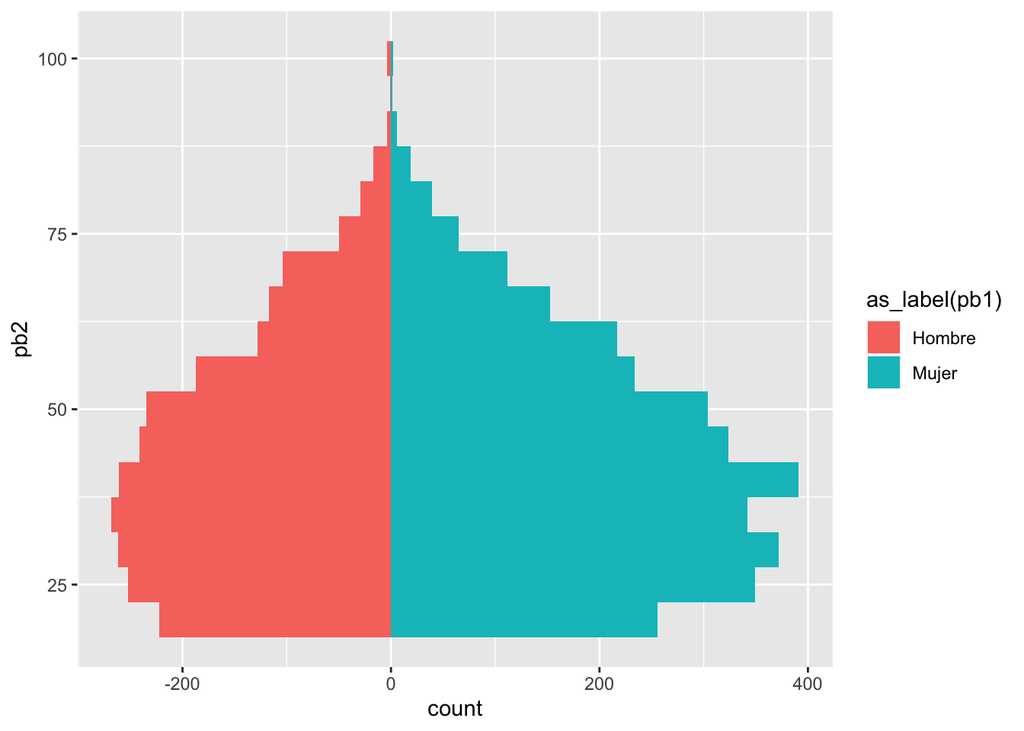

```r
ecovid0420 %>%
  mutate(dummy=if_else(pb1==1,
                       -1,
                       1)) %>%
  ggplot(aes(pb2,
             fill=as_label(pb1),
             weights=dummy))+
    geom_histogram(binwidth = 5) + coord_flip()
```

# Paquete “apyramid”

Necesita que tengamos los datos quinquenales No acepta funciones en las variables edad y sexo

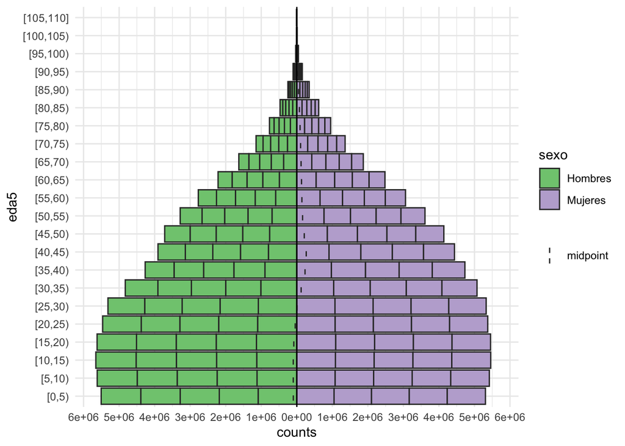

```r
pira <- pob_mit_proyecciones %>%
  filter(cve_geo==0) %>%
  filter(ano==2020) %>%
  age_pyramid(eda5, # edad
              split_by = sexo,
              count=poblacion) # sexo

pira + theme_minimal()
```

Nos ahorra un par de pasos, pero siempre tenemos que solucionar algunos elemtnos

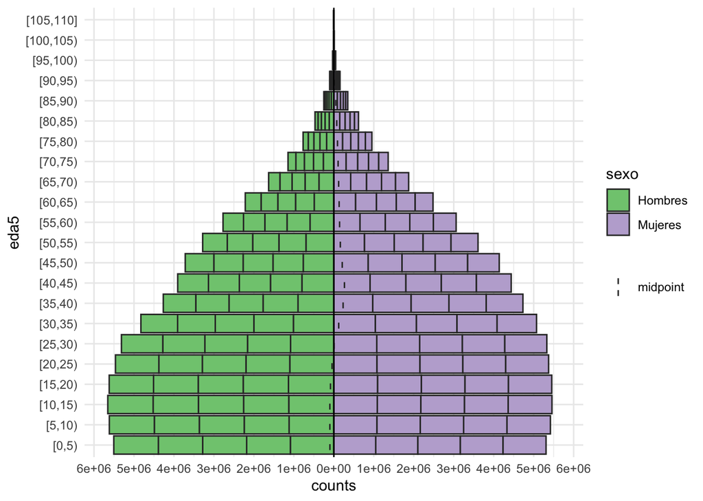

```r
pira <- pob_mit_proyecciones %>%
  filter(cve_geo==0) %>%
  filter(ano==2020) %>%
  age_pyramid(eda5, # edad
              split_by = sexo,
              count=poblacion) # sexo

pira + theme_minimal()
```

# Mapas - fáciles

Un paquete en desarrollo

```r
#if (!require("devtools")) {
#  install.packages("devtools")
# }
#devtools::install_github("diegovalle/mxmaps")
library(mxmaps)
```

## Datos

Índice de competitividad estatal (no internacional)

```r
url <- "https://github.com/aniuxa/R_Demo/raw/master/datos/ICE_2018.xlsx"
destfile <- "ICE_2018.xlsx"
curl::curl_download(url, destfile)

ICE_2018 <- read_excel(destfile, sheet = "para_importar")
```

```
## * `` -> ...102
## * `` -> ...105
```

```r
ICE_2018 <- clean_names(ICE_2018) # limpia los nombres
```

## Lógica del paquete

```r
data("df_mxstate") # carga la base estatal del paquete
glimpse(df_mxstate)
```

```
## Rows: 32
## Columns: 12
## $ region              <chr> "01", "02", "03", "04", "05", "06", "07", "08", "…
## $ state_name          <chr> "Aguascalientes", "Baja California", "Baja Califo…
## $ state_name_official <chr> "Aguascalientes", "Baja California", "Baja Califo…
## $ state_abbr          <chr> "AGS", "BC", "BCS", "CAMP", "COAH", "COL", "CHPS"…
## $ state_abbr_official <chr> "Ags.", "BC", "BCS", "Camp.", "Coah.", "Col.", "C…
## $ pop                 <int> 1312544, 3315766, 712029, 899931, 2954915, 711235…
## $ pop_male            <int> 640091, 1650341, 359137, 441276, 1462612, 350791,…
## $ pop_female          <int> 672453, 1665425, 352892, 458655, 1492303, 360444,…
## $ afromexican         <int> 653, 7445, 11032, 3554, 2761, 762, 4042, 2738, 16…
## $ part_afromexican    <int> 4559, 10432, 5132, 6833, 8137, 3314, 17265, 8886,…
## $ indigenous          <int> 153395, 283055, 103034, 400811, 204890, 145297, 1…
## $ part_indigenous     <int> 18716, 38391, 11728, 13140, 28588, 12373, 52172, …
```

Un primer mapa:

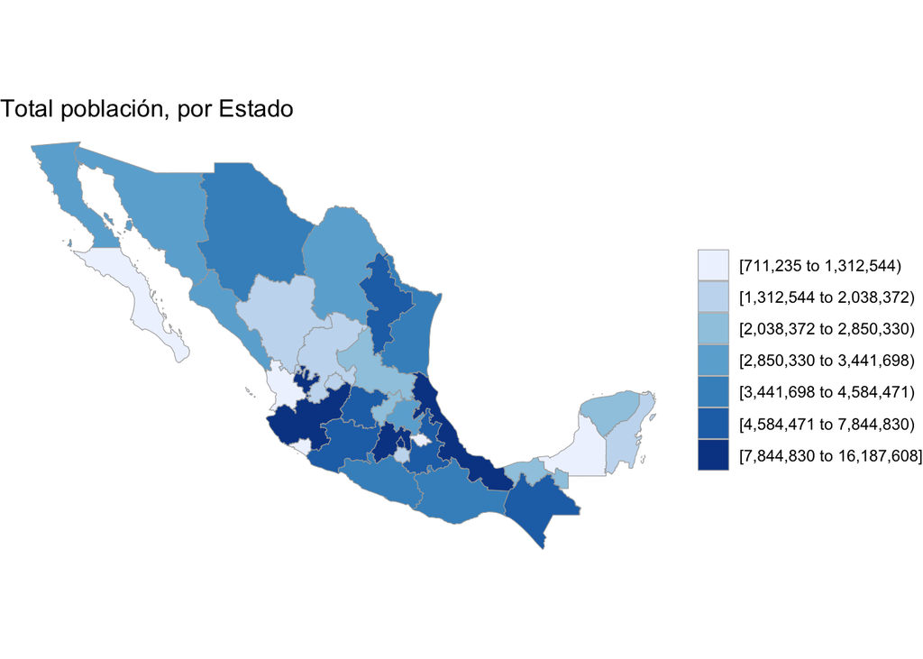

```r
df_mxstate$value<-df_mxstate$pop
mxstate_choropleth(df_mxstate,
                   title = "Total población, por Estado")
```

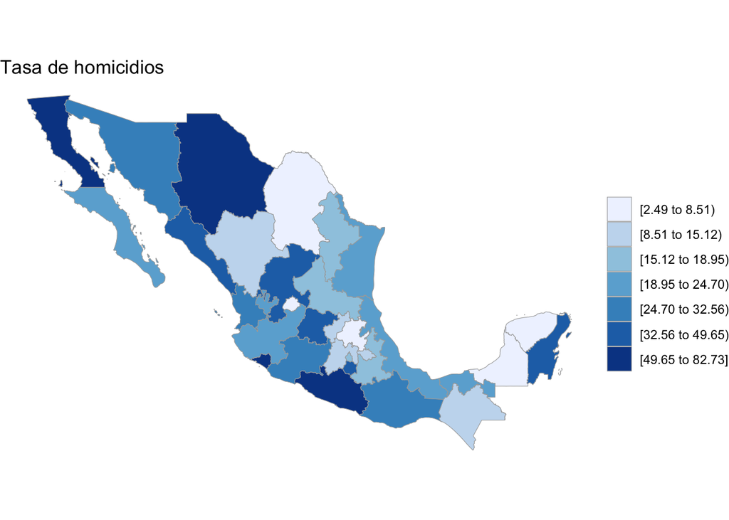

```r
ICE_2018$value<- ICE_2018$homicidios

mxstate_choropleth(ICE_2018,
                   title = "Tasa de homicidios")
```

```r
ggsave(plot=last_plot(), #objeto donde está el gráfico
       device="png", # formato del gráfico
       filename = "mapa.png") # nombre el archivo de salida
```

# Ejercicio

1. Hacer una pirámide con su base específica. Si no se presta para esto, debe hacerlo con la PEA, en lugar del sexo usando la ECOVID.
2. Hacer un mapa sobre una variable de ICE
3. Darse de alta en IPUMS para poderlo usar en la siguiente sesión.

Y saben, a subir:

https://forms.gle/ihA6GQfjHVN4M6No8